# R Notebook

#Modul 8

```r
library(readxl)
data8 <- read_excel("C:/Users/lili/Downloads/pert 8.xlsx")
data8
```

| y1 | y2 | y3 | y4 | y5 | y6 |
| --- | --- | --- | --- | --- | --- |
| 13.4 | 39 | 4100 | 14 | 25 | 17 |
| 14.6 | 46 | 5000 | 15 | 30 | 20 |
| 13.5 | 42 | 4500 | 19 | 21 | 18 |
| 15.0 | 46 | 4600 | 23 | 16 | 18 |
| 14.6 | 44 | 5100 | 17 | 31 | 19 |
| 14.0 | 44 | 4900 | 20 | 24 | 19 |
| 16.4 | 49 | 4300 | 21 | 17 | 18 |
| 14.8 | 44 | 4400 | 16 | 26 | 29 |
| 15.2 | 46 | 4100 | 27 | 13 | 27 |
| 15.5 | 48 | 8400 | 34 | 42 | 36 |

[output cut: 41 more lines]

```r
round(cor(data8),digits=3)
```

```
       y1    y2    y3    y4    y5     y6
y1  1.000 0.774 0.277 0.233 0.055 -0.084
y2  0.774 1.000 0.308 0.252 0.076  0.130
y3  0.277 0.308 1.000 0.791 0.604  0.071
y4  0.233 0.252 0.791 1.000 0.023  0.083
y5  0.055 0.076 0.604 0.023 1.000  0.032
y6 -0.084 0.130 0.071 0.083 0.032  1.000
```

```r
#menghitung eigen vector
eigen(cor(data8))
```

```
eigen() decomposition
$values
[1] 2.44119578 1.38702622 1.02581262 0.93505585 0.19779912 0.01311041

$vectors
            [,1]       [,2]        [,3]        [,4]        [,5]
[1,] -0.43124984  0.5483835  0.14961234  0.10952796  0.69193717
[2,] -0.45311928  0.5053444 -0.08791768  0.20780675 -0.69753267
[3,] -0.55584320 -0.4030830  0.06524550 -0.09953492 -0.01298094
[4,] -0.46271214 -0.2153272 -0.17215474 -0.63631501  0.01071148
[5,] -0.28257537 -0.4725124  0.31280836  0.64796428  0.02088595
[6,] -0.07611479 -0.1085955 -0.91550168  0.33190101  0.18425975
            [,6]
[1,] -0.01191038
[2,] -0.04295357
[3,]  0.71709814
[4,] -0.55216200
[5,] -0.42277679
[6,]  0.01266088
```

```r
#analisis komponen utama
AKU <- princomp(data8,cor=T)
loadings(AKU)
```

```
Loadings:
   Comp.1 Comp.2 Comp.3 Comp.4 Comp.5 Comp.6
y1  0.431  0.548  0.150  0.110  0.692
y2  0.453  0.505         0.208 -0.698
y3  0.556 -0.403                      -0.717
y4  0.463 -0.215 -0.172 -0.636         0.552
y5  0.283 -0.473  0.313  0.648         0.423
y6        -0.109 -0.916  0.332  0.184

               Comp.1 Comp.2 Comp.3 Comp.4 Comp.5 Comp.6
SS loadings     1.000  1.000  1.000  1.000  1.000  1.000
Proportion Var  0.167  0.167  0.167  0.167  0.167  0.167
Cumulative Var  0.167  0.333  0.500  0.667  0.833  1.000
```

```r
#korelasi nilai KU dengan nilai variabel awal
KU <- AKU$scores
cor(data8,KU)
```

```
      Comp.1     Comp.2      Comp.3      Comp.4       Comp.5
y1 0.6737988  0.6458426  0.15153099  0.10591166  0.307736381
y2 0.7079684  0.5951545 -0.08904514  0.20094556 -0.310224957
y3 0.8684676 -0.4747192  0.06608221 -0.09624856 -0.005773225
y4 0.7229565 -0.2535954 -0.17436247 -0.61530571  0.004763890
y5 0.4415050 -0.5564876  0.31681984  0.62657035  0.009288944
y6 0.1189242 -0.1278951 -0.92724215  0.32094259  0.081948813
         Comp.6
y1  0.001363746
y2  0.004918214
y3 -0.082108237
y4  0.063222934
y5  0.048408238
y6 -0.001449679
```

#Modul 9

```r
data(Investment, package="sandwich")
Investment <- as.data.frame(Investment[,1:6])
Investment
```

| GNP | Investment | Price | Interest | RealGNP | RealInv |
| --- | --- | --- | --- | --- | --- |
| 596.7 | 90.9 | 0.7167 | 3.23 | 832.5659 | 126.8313 |
| 637.7 | 97.4 | 0.7277 | 3.55 | 876.3227 | 133.8464 |
| 691.1 | 113.5 | 0.7436 | 4.04 | 929.3975 | 152.6358 |
| 756.0 | 125.7 | 0.7676 | 4.50 | 984.8880 | 163.7572 |
| 799.6 | 122.8 | 0.7906 | 4.19 | 1011.3838 | 155.3251 |
| 873.4 | 133.3 | 0.8254 | 5.16 | 1058.1536 | 161.4975 |
| 944.0 | 149.3 | 0.8679 | 5.87 | 1087.6829 | 172.0244 |
| 992.7 | 144.2 | 0.9145 | 5.95 | 1085.5112 | 157.6818 |
| 1077.6 | 166.4 | 0.9601 | 4.88 | 1122.3831 | 173.3153 |
| 1185.9 | 195.0 | 1.0000 | 4.50 | 1185.9000 | 195.0000 |

[output cut: 10 more lines]

```r
#standardisasi data
zinvestment <- data.frame(scale(Investment))
```

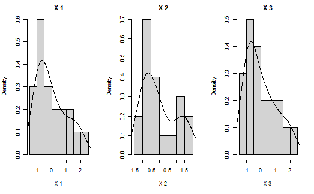

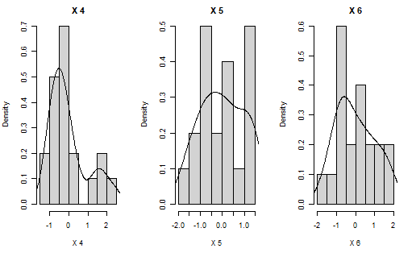

```r
par (mfrow = c(1,3))
for (i in 1:6) {
  hist(zinvestment[,i], prob = T, main = paste("X",i,sep= " "), xlab = paste("X",i,sep= " "))
  lines(density(zinvestment[,i]))
}
```

```r
library(MVN)
mvn(data =zinvestment,mvnTest = "royston")
```

| Test | H | p value | MVN |
| --- | --- | --- | --- |
| Royston | 7.380094 | 0.0234351 | NO |

|  | Test | Variable | Statistic | p value | Normality |
| --- | --- | --- | --- | --- | --- |
| 1 | Anderson-Darling | GNP | 0.7245 | 0.0493 | NO |
| 2 | Anderson-Darling | Investment | 0.9209 | 0.0154 | NO |
| 3 | Anderson-Darling | Price | 0.7279 | 0.0483 | NO |
| 4 | Anderson-Darling | Interest | 1.0673 | 0.0065 | NO |
| 5 | Anderson-Darling | RealGNP | 0.3130 | 0.5204 | YES |
| 6 | Anderson-Darling | RealInv | 0.3923 | 0.3449 | YES |

|  | n | Mean | Std.Dev | Median | Min | Max | 25th | 75th | Skew | Kurtosis |
| --- | --- | --- | --- | --- | --- | --- | --- | --- | --- | --- |
| GNP | 20 | -4.857226e-17 | 1 | -0.29174606 | -1.124918 | 2.003726 | -0.7986361 | 0.6224122 | 0.67604403 | -0.9542482 |
| Investment | 20 | -8.113085e-17 | 1 | -0.27015068 | -1.147840 | 1.925874 | -0.8236594 | 0.8438707 | 0.58362449 | -1.2362325 |
| Price | 20 | 2.222614e-17 | 1 | -0.33664292 | -1.068185 | 2.101557 | -0.8337539 | 0.5956306 | 0.70003321 | -0.8708394 |
| Interest | 20 | -1.671298e-16 | 1 | -0.30416838 | -1.152729 | 2.369403 | -0.7137588 | 0.3413253 | 0.99777586 | -0.2452418 |
| RealGNP | 20 | -3.966554e-16 | 1 | 0.04832706 | -1.697614 | 1.464388 | -0.7048547 | 0.8754060 | -0.02656484 | -1.3519458 |
| RealInv | 20 | -5.407323e-17 | 1 | -0.12800541 | -1.579516 | 1.766614 | -0.7249998 | 0.7641314 | 0.29791744 | -1.1619473 |

```
NA
```

```r
library(REdaS)
library(psych)
bart_spher(zinvestment)
```

```
    Bartlett's Test of Sphericity

Call: bart_spher(x = zinvestment)

     X2 = 326.331
     df = 15
p-value < 2.22e-16
```

• Uji Bartlet Sperisitas untuk menguji apakah setiap variabel saling independen atau tidak • Interpretasi bartlet test Nilai Pvalue <0.05 berarti pada tingkat signifikansi 5% terdapat cukup bukti bahwa matriks korelasi tidak sama dengan matriks identitas. Sehingga variabel tidak saling independent dan dapat digunakan analisis multivariat.

```r
KMO(zinvestment)
```

```
Kaiser-Meyer-Olkin factor adequacy
Call: KMO(r = zinvestment)
Overall MSA =  0.72
MSA for each item =
       GNP Investment      Price   Interest    RealGNP    RealInv
      0.78       0.74       0.72       0.79       0.70       0.62
```

• Interpretasi KMO Semua variabel memiliki nilai MSA>0.5 sehingga dianggap reliabel dan tidak di hapus.

```r
#Menentukan jumlah faktor
R<-cov(zinvestment)
eigen<-eigen(R)
eigen
```

```
eigen() decomposition
$values
[1] 5.5173791599 0.3300284791 0.1151570916 0.0361705689 0.0010496037
[6] 0.0002150969

$vectors
          [,1]        [,2]        [,3]        [,4]        [,5]
[1,] 0.4194705 -0.22343018  0.32000450  0.13760165  0.33486088
[2,] 0.4230439  0.05771685  0.07624479  0.53240938 -0.72647463
[3,] 0.4155335 -0.28516498  0.41772067  0.06975269  0.33813839
[4,] 0.3931743 -0.48686777 -0.77062786 -0.11413025  0.02673516
[5,] 0.4165632  0.21444001  0.18394897 -0.80469596 -0.31224573
[6,] 0.3798674  0.76315392 -0.29931383  0.17938590  0.38412637
            [,6]
[1,]  0.73529214
[2,] -0.02577197
[3,] -0.67254686
[4,] -0.02767562
[5,]  0.04025371
[6,] -0.06305315
```

• Interpretasi cari eigen value >=1, maka disini hanya 1 faktor

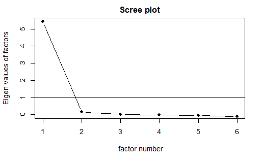

```r
scree(R, pc=FALSE)
```

```
Parallel analysis suggests that the number of factors =  1  and the number of components =  NA
```

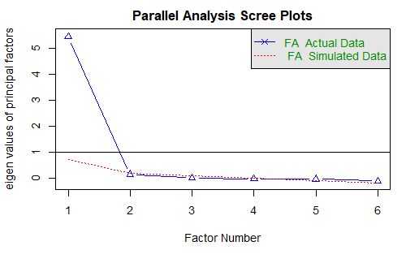

```r
fa.parallel(R, fa="fa")
```

```r
#Extract Factor
Investment_fac<-factanal(factors=2,covmat=R, rotation = "varimax")
Investment_fac
```

```
Call:
factanal(factors = 2, covmat = R, rotation = "varimax")

Uniquenesses:
       GNP Investment      Price   Interest    RealGNP    RealInv
     0.005      0.007      0.005      0.161      0.039      0.005

Loadings:
           Factor1 Factor2
GNP        0.871   0.490
Investment 0.766   0.637
Price      0.892   0.449
Interest   0.812   0.424
RealGNP    0.710   0.676
RealInv    0.427   0.902

               Factor1 Factor2
SS loadings      3.487   2.297
Proportion Var   0.581   0.383
Cumulative Var   0.581   0.964

The degrees of freedom for the model is 4 and the fit was 3.7934
```

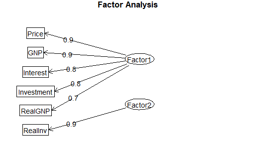

```r
loads <- Investment_fac$loadings

fa.diagram(loads)
```

```r
library(psych)
fac <- fa(zinvestment, nfactors=2, rotate ="varimax", covar=FALSE, fm="pa")
fac
```

```
Factor Analysis using method =  pa
Call: fa(r = zinvestment, nfactors = 2, rotate = "varimax", covar = FALSE,
    fm = "pa")
Standardized loadings (pattern matrix) based upon correlation matrix
```

|  | PA1 | PA2 | h2 | u2 | com |
| --- | --- | --- | --- | --- | --- |
| GNP | 0.88 | 0.48 | 1.0022131 | -0.002213080 | 1.547697 |
| Investment | 0.78 | 0.62 | 0.9904203 | 0.009579655 | 1.910566 |
| Price | 0.89 | 0.45 | 0.9933492 | 0.006650770 | 1.470024 |
| Interest | 0.82 | 0.41 | 0.8415925 | 0.158407463 | 1.475714 |
| RealGNP | 0.71 | 0.67 | 0.9582666 | 0.041733363 | 1.992551 |
| RealInv | 0.44 | 0.90 | 0.9970222 | 0.002977786 | 1.445102 |

```
                       PA1  PA2
SS loadings           3.54 2.24
Proportion Var        0.59 0.37
Cumulative Var        0.59 0.96
Proportion Explained  0.61 0.39
Cumulative Proportion 0.61 1.00

Mean item complexity =  1.6
Test of the hypothesis that 2 factors are sufficient.

The degrees of freedom for the null model are  15  and the objective function was  20.19 with Chi Square of  326.33
The degrees of freedom for the model are 4  and the objective function was  2.6

The root mean square of the residuals (RMSR) is  0
The df corrected root mean square of the residuals is  0.01

The harmonic number of observations is  20 with the empirical chi square  0.01  with prob <  1
The total number of observations was  20  with Likelihood Chi Square =  38.53  with prob <  8.7e-08

Tucker Lewis Index of factoring reliability =  0.545
RMSEA index =  0.655  and the 90 % confidence intervals are  0.49 0.876
BIC =  26.54
Fit based upon off diagonal values = 1
```

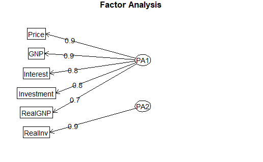

```r
loads1 <- fac$loadings

fa.diagram(loads1)
```

• Rotation mencegah ada 1 variabel yang masuk 2 faktor • Cumulative menceritakan seberapa faktor itu dapat menggambarkan data, sehingga 58% data dapat dijelaskan oleh factor 1 dan dengan menggunakan 2 buah faktor yaitu factor 1 dan 2 maka dapat tergambar 96% dari data • pada loadings, cek variabel yang paling berpengaruh di setiap faktornya, maka akan masuk ke faktor tersebut • Menggunakan diagram dapat terlihat variabel mana2 saja yang masuk suatu faktor. Jangan lupa namakan faktornya diliat dari variabel2 yang sesuai

Contoh lain

```r
library(readxl)
life <- read_excel("C:/Users/lili/Downloads/life data.xlsx")
life
```

| m0 | m25 | m50 | m75 | w0 | w25 | w50 | w75 |
| --- | --- | --- | --- | --- | --- | --- | --- |
| 63 | 51 | 30 | 13 | 67 | 54 | 34 | 15 |
| 34 | 29 | 13 | 5 | 38 | 32 | 17 | 6 |
| 38 | 30 | 17 | 7 | 38 | 34 | 20 | 7 |
| 59 | 42 | 20 | 6 | 64 | 46 | 25 | 8 |
| 56 | 38 | 18 | 7 | 62 | 46 | 25 | 10 |
| 62 | 44 | 24 | 7 | 69 | 50 | 28 | 14 |
| 50 | 39 | 20 | 7 | 55 | 43 | 23 | 8 |
| 65 | 44 | 22 | 7 | 72 | 50 | 27 | 9 |
| 56 | 46 | 24 | 11 | 63 | 54 | 33 | 19 |
| 69 | 47 | 24 | 8 | 75 | 53 | 29 | 10 |

[output cut: 2 more lines]

```r
NA
```

```r
R1 <- cor(life)
eigen(R1)
```

```
eigen() decomposition
$values
[1] 6.511080569 1.008772479 0.393991114 0.053555658 0.018598879
[6] 0.009567193 0.002605459 0.001828649

$vectors
           [,1]        [,2]        [,3]        [,4]        [,5]
[1,] -0.3486081  0.44948287 -0.03419857 -0.04807949 -0.31292936
[2,] -0.3825963  0.10719566 -0.23253736  0.21101139  0.76480569
[3,] -0.3691220 -0.08578984 -0.45362827  0.63066757 -0.38242139
[4,] -0.3102859 -0.52711366 -0.44636700 -0.48842242  0.01522675
[5,] -0.3421420  0.46764416  0.19576228 -0.10462643 -0.06977774
[6,] -0.3846303  0.12119298  0.20406775 -0.23912589  0.23911329
[7,] -0.3815435 -0.16429791  0.17228340 -0.33475701 -0.32789998
[8,] -0.2983069 -0.49080844  0.65580991  0.36969498  0.03327181
            [,6]        [,7]       [,8]
[1,]  0.38640895  0.62551802 -0.1855988
[2,] -0.22625685  0.28410811  0.1633782
[3,] -0.10130373 -0.28537464 -0.1221541
[4,]  0.39682721 -0.04355184  0.1687407
[5,]  0.13484136 -0.45907288  0.6173971
[6,]  0.04046371 -0.42386521 -0.7071582
[7,] -0.73078988  0.19761987  0.0711412
[8,]  0.27908480  0.12333332  0.0956691
```

• Interpretasi cari eigen value >=1, maka disini hanya 2 faktor

```r
sapply(1:4, function(f)
  round(factanal(life, factors=f, method="mle")$PVAL,4))
```

```
objective objective objective objective
   0.0000    0.0007    0.2642    0.1219
```

```r
factanal(life, factors = 3, method = "mle")
```

```
Call:
factanal(x = life, factors = 3, method = "mle")

Uniquenesses:
   m0   m25   m50   m75    w0   w25   w50   w75
0.005 0.020 0.030 0.028 0.005 0.005 0.010 0.065

Loadings:
    Factor1 Factor2 Factor3
m0  0.948   0.272   0.152
m25 0.758   0.563   0.298
m50 0.592   0.736   0.278
m75 0.180   0.840   0.483
w0  0.958   0.152   0.236
w25 0.794   0.362   0.484
w50 0.587   0.503   0.627
w75 0.234   0.347   0.872

               Factor1 Factor2 Factor3
SS loadings      3.804   2.165   1.866
Proportion Var   0.475   0.271   0.233
Cumulative Var   0.475   0.746   0.979

Test of the hypothesis that 3 factors are sufficient.
The chi square statistic is 8.84 on 7 degrees of freedom.
The p-value is 0.264
```

```r
factanal(life, factors = 3, covmat=R1, method = "mle", rotation = "none")
```

```
Call:
factanal(x = life, factors = 3, covmat = R1, rotation = "none",     method = "mle")

Uniquenesses:
   m0   m25   m50   m75    w0   w25   w50   w75
0.005 0.020 0.030 0.028 0.005 0.005 0.010 0.065

Loadings:
    Factor1 Factor2 Factor3
m0   0.967  -0.228
m25  0.963   0.137   0.184
m50  0.876   0.318   0.317
m75  0.635   0.716   0.235
w0   0.963  -0.259
w25  0.989   0.103
w50  0.914   0.381
w75  0.643   0.611  -0.385

               Factor1 Factor2 Factor3
SS loadings      6.189   1.280   0.366
Proportion Var   0.774   0.160   0.046
Cumulative Var   0.774   0.934   0.979

The degrees of freedom for the model is 7 and the fit was 1.6076
```

• Faktor pertama didominasi oleh harapan hidup saat lahir bagi laki-laki dan perempuan; mungkin faktor ini bisa diberi label “ketahanan hidup saat lahir”

• Faktor kedua mencerminkan harapan hidup pada usia yang lebih tua, dan kita mungkin menyebutnya “ketahanan hidup di antara orang tua”.

#Modul 10

Biplot

```r
library(psych)
library(GPArotation)
```

```r
library(readxl)
jatim <- read_excel("C:/Users/lili/Downloads/Data10.xlsx")
jatim <- jatim[,-1]
jatim
```

| Density | PddkKOta | Depend | Gini | Miskin | KapitaNMkn |
| --- | --- | --- | --- | --- | --- |
| 422 | 21.77 | 49.26 | 0.35 | 14.54 | 47.27 |
| 727 | 34.73 | 46.56 | 0.38 | 9.95 | 54.96 |
| 637 | 35.78 | 45.48 | 0.38 | 11.62 | 50.93 |
| 1032 | 52.95 | 47.89 | 0.34 | 7.33 | 51.19 |
| 916 | 45.00 | 49.22 | 0.35 | 9.33 | 52.71 |
| 1180 | 52.54 | 47.03 | 0.33 | 11.40 | 49.03 |
| 752 | 54.82 | 45.74 | 0.37 | 10.15 | 53.01 |
| 625 | 35.11 | 43.36 | 0.30 | 9.83 | 42.72 |
| 820 | 50.80 | 45.39 | 0.32 | 10.09 | 44.88 |
| 295 | 60.21 | 46.29 | 0.32 | 8.06 | 49.55 |

[output cut: 28 more lines]

```r
eigen(cor(jatim))
```

```
eigen() decomposition
$values
[1] 3.85764446 1.07339540 0.52011475 0.33758527 0.12901024
[6] 0.08224987

$vectors
           [,1]       [,2]         [,3]         [,4]        [,5]
[1,] -0.4264042  0.2959406 -0.223798840  0.690607630 -0.12999713
[2,] -0.4652120  0.1934685 -0.380969410 -0.005459132  0.01733351
[3,]  0.3066648 -0.5567516 -0.754435292  0.156379392  0.01231611
[4,] -0.2930590 -0.6904204  0.444794459  0.349977264 -0.25928414
[5,]  0.4547388  0.1369349  0.194317992  0.589432474  0.53163445
[6,] -0.4637273 -0.2637904 -0.001478298 -0.169298725  0.79547794
           [,6]
[1,]  0.4320585
[2,] -0.7750354
[3,]  0.0469637
[4,] -0.2233421
[5,] -0.3265519
[6,]  0.2322116
```

• Interpretasi cari eigen value >=1, maka disini hanya 2 faktor

```r
fa1 <- fa(jatim,nfactors=2,fm="pa",scores=TRUE)
fa1
```

```
Factor Analysis using method =  pa
Call: fa(r = jatim, nfactors = 2, scores = TRUE, fm = "pa")
Standardized loadings (pattern matrix) based upon correlation matrix
```

|  | PA1 | PA2 | h2 | u2 | com |
| --- | --- | --- | --- | --- | --- |
| Density | 0.88 | -0.02 | 0.7540090 | 0.24599095 | 1.000881 |
| PddkKOta | 0.91 | 0.09 | 0.9304005 | 0.06959951 | 1.017315 |
| Depend | -0.67 | 0.13 | 0.3652715 | 0.63472845 | 1.075948 |
| Gini | -0.18 | 0.85 | 0.5816370 | 0.41836305 | 1.092999 |
| Miskin | -0.48 | -0.51 | 0.7567830 | 0.24321697 | 1.993767 |
| KapitaNMkn | 0.32 | 0.76 | 0.9586986 | 0.04130140 | 1.348080 |

```
                       PA1  PA2
SS loadings           2.59 1.75
Proportion Var        0.43 0.29
Cumulative Var        0.43 0.72
Proportion Explained  0.60 0.40
Cumulative Proportion 0.60 1.00

 With factor correlations of
     PA1  PA2
PA1 1.00 0.57
PA2 0.57 1.00

Mean item complexity =  1.3
Test of the hypothesis that 2 factors are sufficient.

The degrees of freedom for the null model are  15  and the objective function was  4.86 with Chi Square of  166.21
The degrees of freedom for the model are 4  and the objective function was  0.24

The root mean square of the residuals (RMSR) is  0.03
The df corrected root mean square of the residuals is  0.05

The harmonic number of observations is  38 with the empirical chi square  0.79  with prob <  0.94
The total number of observations was  38  with Likelihood Chi Square =  7.81  with prob <  0.099

Tucker Lewis Index of factoring reliability =  0.901
RMSEA index =  0.156  and the 90 % confidence intervals are  0 0.328
BIC =  -6.74
Fit based upon off diagonal values = 1
Measures of factor score adequacy
                                                   PA1  PA2
Correlation of (regression) scores with factors   0.97 0.97
Multiple R square of scores with factors          0.95 0.94
Minimum correlation of possible factor scores     0.89 0.88
```

Berdasarkan analisis faktor tersebut, kedua faktor dapat menjelaskan keragaman data sebesar 73 persen, dengan factor 1 (43 persen) dan factor 2 (29.9 persen). Variabel- variable yang berkorelasi tinggi dengan factor 1 adalah: Kepadatan penduduk (density), persentase penduduk perkotaan (PddkKota), dan rasio ketergantungan penduduk (Depend). Sementara variable yang berkorelasi dengan factor 2 adalah: gini ratio, persenstase penduduk miskin dan pengeluaran per kapita non makanan (KapitaNMkn). Skor faktor pada output tersebut, tidak dapat dilihat langsung. Namun system di R sudah menghitungnya, sehingga dapat dibuat biplot nya

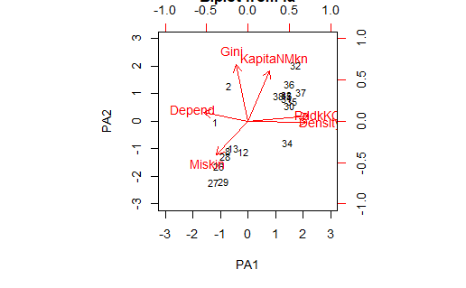

```r
biplot(fa1,labels=rownames(jatim))
```

Garis merah melambangkan vektor ciri (eigen vector). Semakin panjang eigen vector menunjukkan bahwa semakin besar kontribusi variable tersebut terhadap pembentukan factor. Berdasarkan biplot tersebut, dapat diketahui bahwa variable persentase penduduk kota (PddkKota) mempunyai peranan terbesar dalam pembentukan factor 1, disusul oleh variable kepadatan penduduk (Density) dan variable rasio ketergantungan (Dependency).

Garis-garis eigen vector yang membentuk sudut semakin lancip menunjukkan bahwa ada korelasi yang tinggi diantara variabel. Pada Gambar biplot tersebut dapat dilihat bahwa variable persentase penduduk perkotaan (PddkKota) dengan kepadatan penduduk berkorelasi sangat tinggi (Density).

Berdasarkan biplot tersebut, dapat dilihat bahwa terdapat pengelompokkan objek. Misalnya,

• Kelompok 1, terdiri dari kabupaten/kota dengan nomor urut ke 27, 29, 26, 28, 8, 13 dan 12. Kelompok ini mempunyai karakteristik memiliki persentase penduduk miskin yang relative lebih tinggi dibanding kabupaten/kota lainnya. • Kelompok 2, terdiri dari kabupaten/kota dengan nomor urut ke 32, 36, 38, 35, 37, 30, 31, 25. Kelompok ini mempunyai karakteristik pengeluaran per kapita non makanan yang relative lebih tinggi dan persentase penduduk kota serta kepadatan penduduk yang relative lebih tinggi. Kelompok ini bisa dikatakan kelompok perkotaan dengan tingkat kemiskinan yang rendah. • Sementara itu ada juga kabupaten yang tidak ikut kedua kelompok tersebut, misalnya nomor urut 1 mempunyai ciri rasio ketergantungan penduduk yang relative lebih tinggi dibanding kabupaten kota lainnya, sedangkan untuk variable lainnya cenderung rendah

Korespondensi

```r
library(FactoMineR)
library(factoextra)
library(ggplot2)
library(gplots)
```

```r
data("housetasks")
head(housetasks)
```

|  | Wife | Alternating | Husband | Jointly |
| --- | --- | --- | --- | --- |
| Laundry | 156 | 14 | 2 | 4 |
| Main_meal | 124 | 20 | 5 | 4 |
| Dinner | 77 | 11 | 7 | 13 |
| Breakfeast | 82 | 36 | 15 | 7 |
| Tidying | 53 | 11 | 1 | 57 |
| Dishes | 32 | 24 | 4 | 53 |

```r
library(gplots)
data1 <- as.table(as.matrix(housetasks))
data1
```

```
           Wife Alternating Husband Jointly
Laundry     156          14       2       4
Main_meal   124          20       5       4
Dinner       77          11       7      13
Breakfeast   82          36      15       7
Tidying      53          11       1      57
Dishes       32          24       4      53
Shopping     33          23       9      55
Official     12          46      23      15
Driving      10          51      75       3
Finances     13          13      21      66
Insurance     8           1      53      77
Repairs       0           3     160       2
Holidays      0           1       6     153
```

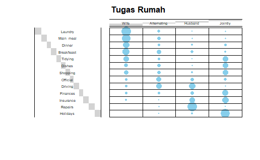

```r
balloonplot(t(data1), main ="Tugas Rumah", xlab ="", ylab="",label = FALSE, show.margins = FALSE,dotsize=4, text.size=0.5)
```

- Pekerjaan rumah seperti Binatu (Laundry), Makanan Utama (Main_meal) dan Makan Malam (Dinner) lebih sering dilakukan oleh “Istri”(Wife).
- Perbaikan-perbaikan (Repairs) dan menyetir (Driving) lebih banyak dilakukan oleh “suami” (Husband).
- Liburan (Holidays) sering dilakukan secara “bersama-sama” (Jointly)

```r
an.ca <- CA(housetasks, graph = FALSE)
print(an.ca)
```

```
**Results of the Correspondence Analysis (CA)**
The row variable has  13  categories; the column variable has 4 categories
The chi square of independence between the two variables is equal to 1944.456 (p-value =  0 ).
*The results are available in the following objects:

   name              description
1  "$eig"            "eigenvalues"
2  "$col"            "results for the columns"
3  "$col$coord"      "coord. for the columns"
4  "$col$cos2"       "cos2 for the columns"
5  "$col$contrib"    "contributions of the columns"
6  "$row"            "results for the rows"
7  "$row$coord"      "coord. for the rows"
8  "$row$cos2"       "cos2 for the rows"
9  "$row$contrib"    "contributions of the rows"
10 "$call"           "summary called parameters"
11 "$call$marge.col" "weights of the columns"
12 "$call$marge.row" "weights of the rows"
```

```r
summary(an.ca)
```

```
Call:
CA(X = housetasks, graph = FALSE)

The chi square of independence between the two variables is equal to 1944.456 (p-value =  0 ).

Eigenvalues
                       Dim.1   Dim.2   Dim.3
Variance               0.543   0.445   0.127
% of var.             48.692  39.913  11.395
Cumulative % of var.  48.692  88.605 100.000

Rows (the 10 first)
              Iner*1000     Dim.1     ctr    cos2     Dim.2     ctr
Laundry     |   134.160 |  -0.992  18.287   0.740 |   0.495   5.564
Main_meal   |    90.692 |  -0.876  12.389   0.742 |   0.490   4.736
Dinner      |    38.246 |  -0.693   5.471   0.777 |   0.308   1.321
Breakfeast  |    41.124 |  -0.509   3.825   0.505 |   0.453   3.699
Tidying     |    24.667 |  -0.394   1.998   0.440 |  -0.434   2.966
Dishes      |    19.587 |  -0.189   0.426   0.118 |  -0.442   2.844
Shopping    |    14.970 |  -0.118   0.176   0.064 |  -0.403   2.515
Official    |    53.300 |   0.227   0.521   0.053 |   0.254   0.796
Driving     |   101.509 |   0.742   8.078   0.432 |   0.653   7.647
Finances    |    29.564 |   0.271   0.875   0.161 |  -0.618   5.559
               cos2     Dim.3     ctr    cos2
Laundry       0.185 |  -0.317   7.968   0.075 |
Main_meal     0.232 |  -0.164   1.859   0.026 |
Dinner        0.154 |  -0.207   2.097   0.070 |
Breakfeast    0.400 |   0.220   3.069   0.095 |
Tidying       0.535 |  -0.094   0.489   0.025 |
Dishes        0.646 |   0.267   3.634   0.236 |
Shopping      0.748 |   0.203   2.223   0.189 |
Official      0.066 |   0.923  36.940   0.881 |
Driving       0.335 |   0.544  18.596   0.233 |
Finances      0.837 |   0.035   0.062   0.003 |

Columns
              Iner*1000     Dim.1     ctr    cos2     Dim.2     ctr
Wife        |   301.019 |  -0.838  44.462   0.802 |   0.365  10.312
Alternating |   117.824 |  -0.062   0.104   0.005 |   0.292   2.783
Husband     |   381.373 |   1.161  54.234   0.772 |   0.602  17.787
Jointly     |   314.725 |   0.149   1.200   0.021 |  -1.027  69.118
               cos2     Dim.3     ctr    cos2
Wife          0.152 |  -0.200  10.822   0.046 |
Alternating   0.105 |   0.849  82.549   0.890 |
Husband       0.208 |  -0.189   6.133   0.020 |
Jointly       0.977 |  -0.046   0.495   0.002 |
```

Dari output tersebut didapatkan: nilai Chi square yang menunjukkan statistik uji untuk independence test antar kategori baris dan kolom adalah sebesar 1944.456 (p-value =0 ). Nilai Chi square yang tinggi tersebut menunjukkan ada hubungan/ketergantunganantar kategori baris dan kolom.

Terbentuk 3 dimensi, dimensi 1 menjelaskan 48.692% dari total inertia (variasi data), dimensi 2 sebesar 39.913% dan dimensi 3 sebesar 11.395%. Namun jika kita menggunakan dua dimensi pertama (dimensi 1 dan 2) saja, total inertia (varians) yang bisa dijelaskan sudah cukup tinggi yaitu sebesar 88.605%.

Output juga menghasilkan skor setiap dimensi untuk kategori baris dan kolom(ini tidak lain adalah titik-titik koordinat). Namun cukup sulit diinterpretasikan. Oleh karena itu perlu digunakan visualisasi grafik.

```r
df1 <- (nrow(housetasks) - 1) * (ncol(housetasks) - 1)
qchisq(1-0.05,df=df1)
```

```
[1] 50.99846
```

Nilai Chi-square tabel pada saat alpha=0.05% dan derajat bebas df=(nr-1)*(nc-1) adalah sebesar 50.99846. Kita lihat nilai Chi-square hitung = 1944.456 > Chi-square tabel. Hal ini menghasilkan keputusan “tolak H0” (antar kategori baris dan kolom independent), artinya ada hubungan antar kategori baris dan kolom

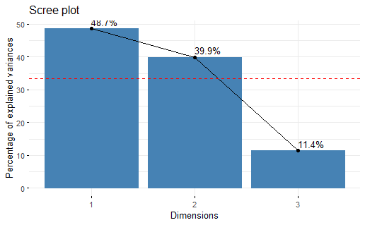

```r
fviz_screeplot(an.ca,addlabels = TRUE) +
geom_hline(yintercept=33.33, linetype=2, color="red")
```

Data “housetasks” berisi 13 baris dan 4 kolom. Nilai yang diharapkan dari nilai eigen (eigen rata-rata) untuk setiap sumbu adalah 1/(nrow (housetasks) -1) = 1/12 = 8.33% dalam bentuk baris. 1/(ncol (tugas rumah) -1) = 1/3 = 33.33% dalam bentuk kolom. Setiap sumbu dengan kontribusi yang maksimum dari dua persentase ini harus dianggap penting dan termasuk dalam solusi untuk interpretasi data. Oleh karena itu untuk menentukan banyaknya dimensi dapat dilihat dari screeplot dengan cut off =33.33%

Menurut grafik di atas, cukup digunakan dimensi 1 dan 2. Dimensi 3 menjelaskan hanya 11,4% dari total inertia yang berada di bawah nilai eigen rata-rata (33,33%) dan terlalu sedikit untuk disimpan dalam analisis lebih lanjut.

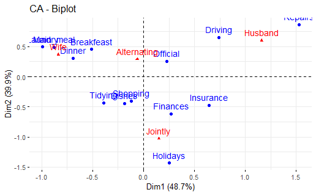

```r
library(Rcpp)
# repel= TRUE untuk menghindari text tumpang tindih(running lambat jika titiknya banyak)
fviz_ca_biplot(an.ca, repel = F)
```

Plot simetris mewakili profil baris dan kolom secara bersamaan dalam ruang bersama. Biplot simetris ini menunjukkan pola umum data. Warna biru adalah kategori untuk baris dan merah untuk kolom. Dalam hal ini, hanya jarak antar titik dalam baris atau jarak antar titik dalam kolom yang dapat diinterpretasikan. Sementara itu, jarak antara item baris dan kolom tidak memiliki makna. Jarak antara titik baris atau titik kolom memberikan ukuran similarity (atau disimilarity). Titik yang berdekatan menunjukkan adanya kesamaan profil

- Pekerjaan rumah seperti menyiapkan makan malam (Dinner), sarapan (Breakfast), mencuci pakaian (Laundry) mempunyai profil yang sama. Pekerjaan tersebut lebih sering dilakukan oleh istri (Wife).
- Mengemudi (Driving) dan perbaikan (Repairs) lebih sering dilakukan oleh suami (Husband).
- Belanja (Shopping), urusan keuangan (Insurance & Finance), kegiatan bersih-bersih rumah (Tidying & Dishes) dan hiburan (Holidays) lebih sering dilakukan secara bersama-sama antara suami istri.

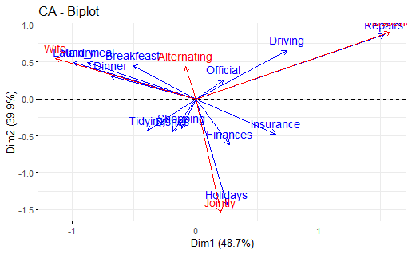

```r
fviz_ca_biplot(an.ca,map ="rowprincipal", arrow = c(TRUE, TRUE),
repel = F)
```

Jika sudut antara dua anak panah (biru dan merah) lancip, maka itu adalah hubungan yang kuat antara baris dan kolom yang bersesuaian. Pada gambar tersebut menunjukkan bahwa - Pekerjaan rumah seperti mencuci pakaian (Laundry), menyiapkan makanan (Main_meal), makan malam (Dinner) sangat erat berhubungan dengan istri (Wife). - Pekerjaan perbaikan (Repairs) sangat erat berhubungan dengan suami (Husband), sementara mengemudi (Driving) cukup erat berhubungan dengan suami. - Hiburan (Holidays) sangat erat berhubungan dengan perkerjaan bersama-sama (Jointly), sementara keuangan (Finances) dan belanja (Shopping), urusan asuransi, dan pemeliharaan kebersihan rumah (Tidying dan Dishes) cukup erat berhubungan dengan “jointly”. - Sementara pekerjaan “Official” erat berhubungan dengan pekerjaan yang dilakukan secara bergantian (Alternating) dan pekerjaan suami (Husband).

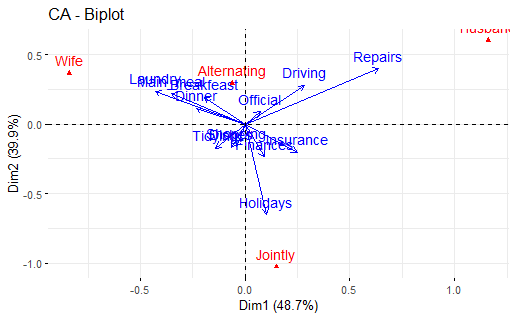

```r
fviz_ca_biplot(an.ca, map ="colgreen", arrow = c(TRUE, FALSE),
repel = F)
```

Semakin dekat panah (dalam hal jarak sudut) ke sumbu dan panjang vektor /panah semakin panjang, maka semakin besar kontribusi kategori baris pada sumbu itu relatif terhadap sumbu lainnya. Jika panah berada di tengah antara keduanya, kategori barisnya berkontribusi pada dua sumbu pada tingkat yang sama. Pada Gambar tersebut dapat kita lihat bahwa: - Kategori baris “Repairs” memiliki kontribusi penting terhadap kutub positif dimensi pertama (Dim1), sedangkan kategori “Laundry” dan “Main_meal” memiliki kontribusi besar terhadap kutub negatif dimensi pertama; - Dimensi 2 terutama ditentukan oleh kategori baris “Holidays”. - Kategori baris “Driving” berkontribusi pada dua sumbu pada tingkat yang sama.

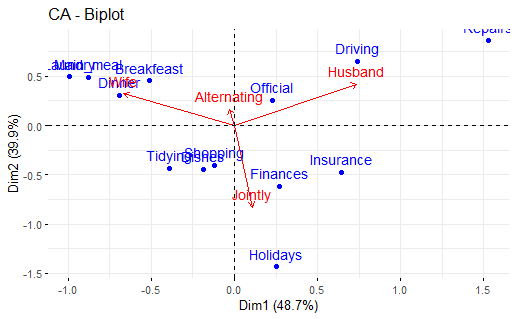

```r
fviz_ca_biplot(an.ca, map ="rowgreen", arrow = c(FALSE, TRUE), repel
= F)
```

• Kategori “Husband” berkontribusi penting dalam pembentukan Dimensi pertama di kutub positif dan kategori “Wife” di kutub negatif • Kategori “Jointly” berkontribusi penting dalam Dimensi 2.

```r
# Dimension description
deskripsi.dimensi <- dimdesc(an.ca, axes = c(1,2))
deskripsi.dimensi
```

```
$`Dim 1`
$`Dim 1`$row
                coord
Laundry    -0.9918368
Main_meal  -0.8755855
Dinner     -0.6925740
Breakfeast -0.5086002
Tidying    -0.3938084
Dishes     -0.1889641
Shopping   -0.1176813
Official    0.2266324
Holidays    0.2524863
Finances    0.2707669
Insurance   0.6470759
Driving     0.7417696
Repairs     1.5287787

$`Dim 1`$col
                  coord
Wife        -0.83762154
Alternating -0.06218462
Jointly      0.14942609
Husband      1.16091847


$`Dim 2`
$`Dim 2`$row
                coord
Holidays   -1.4350066
Finances   -0.6178684
Insurance  -0.4737832
Dishes     -0.4419662
Tidying    -0.4343444
Shopping   -0.4033171
Official    0.2536132
Dinner      0.3081043
Breakfeast  0.4528038
Main_meal   0.4901092
Laundry     0.4953220
Driving     0.6534143
Repairs     0.8642647

$`Dim 2`$col
                 coord
Jointly     -1.0265791
Alternating  0.2915938
Wife         0.3652207
Husband      0.6019199
```

Dengan demikian kita dapat melabeli Dimensi 1 sebagai “Pekerjaan/tugas rumah yang dilakukan suami atau istri”, sementara Dimensi 2 sebagai “Pekerjaan/tugas rumah yang dilakukan suami dan istri bersamaan”.